# EDA Template

# Inferential Model

## Baseline Inferential Model

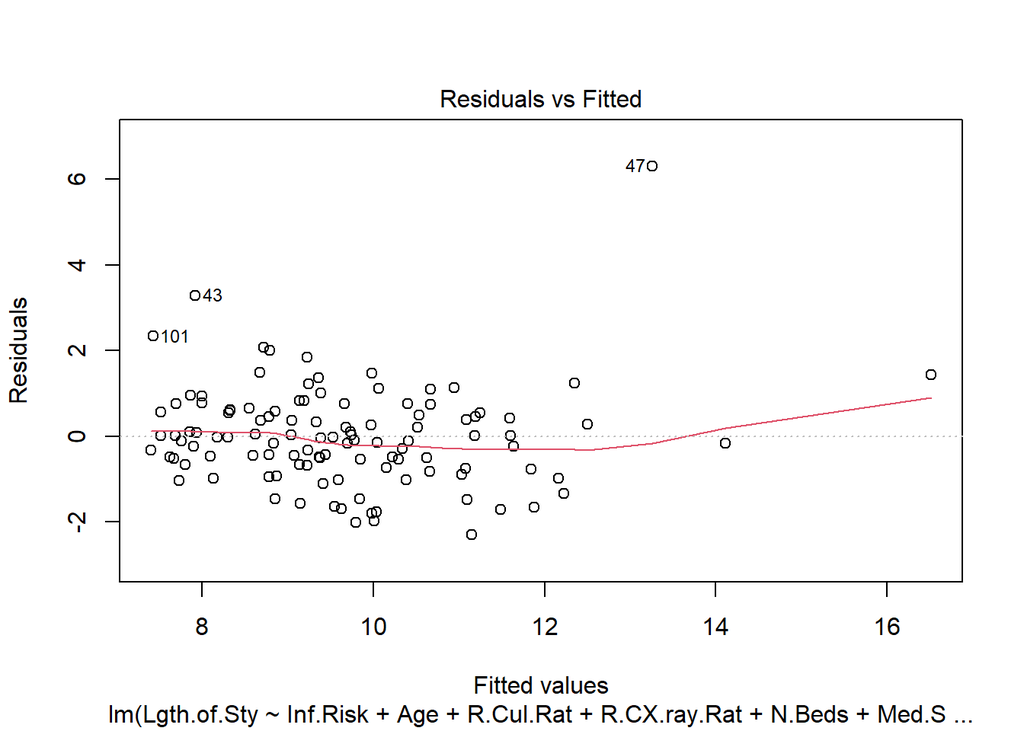

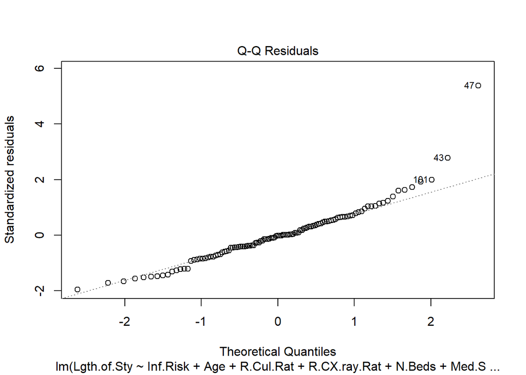

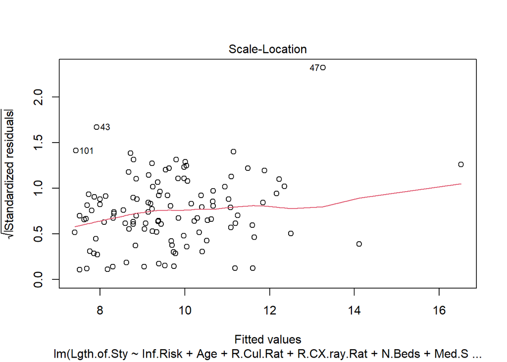

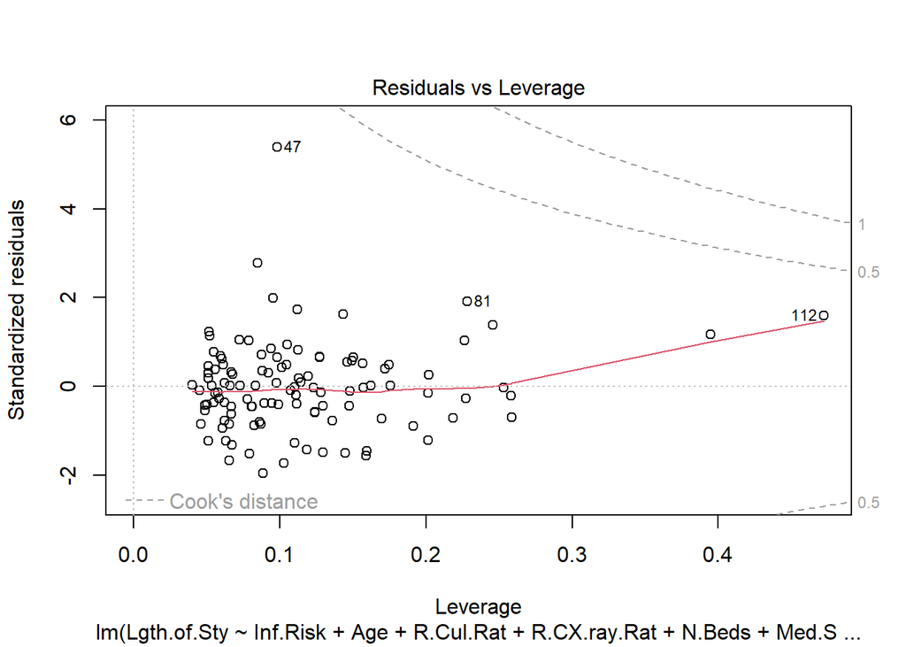

```r
fit1 = lm(Lgth.of.Sty ~  Inf.Risk + Age + R.Cul.Rat + R.CX.ray.Rat + N.Beds + Med.Sc.Aff + Region + Avg.Pat + Avg.Nur + Pct.Ser.Fac, data = df)
plot(fit1)
```

```r
summary(fit1)
```

```
##
## Call:
## lm(formula = Lgth.of.Sty ~ Inf.Risk + Age + R.Cul.Rat + R.CX.ray.Rat +
##     N.Beds + Med.Sc.Aff + Region + Avg.Pat + Avg.Nur + Pct.Ser.Fac,
##     data = df)
##
## Residuals:
##     Min      1Q  Median      3Q     Max
## -2.3048 -0.6608 -0.0272  0.5862  6.3001
##
## Coefficients:
##               Estimate Std. Error t value Pr(>|t|)
## (Intercept)   3.322292   1.782122   1.864 0.065222 .
## Inf.Risk      0.439665   0.127298   3.454 0.000812 ***
## Age           0.079922   0.028266   2.827 0.005668 **
## R.Cul.Rat     0.005546   0.015982   0.347 0.729299
## R.CX.ray.Rat  0.012688   0.007147   1.775 0.078892 .
## N.Beds       -0.004851   0.003603  -1.346 0.181224
## Med.Sc.AffNo -0.266644   0.441089  -0.605 0.546872
## RegionNC     -0.812966   0.351406  -2.313 0.022744 *
## RegionS      -1.158277   0.351704  -3.293 0.001370 **
## RegionW      -1.880560   0.444136  -4.234  5.1e-05 ***
## Avg.Pat       0.015182   0.004424   3.432 0.000872 ***
## Avg.Nur      -0.005891   0.002218  -2.656 0.009203 **
## Pct.Ser.Fac  -0.012179   0.013774  -0.884 0.378698
## ---
## Signif. codes:  0 '***' 0.001 '**' 0.01 '*' 0.05 '.' 0.1 ' ' 1
##
## Residual standard error: 1.231 on 100 degrees of freedom
## Multiple R-squared:  0.6299, Adjusted R-squared:  0.5855
## F-statistic: 14.18 on 12 and 100 DF,  p-value: < 2.2e-16
```

```r
vif(fit1)
```

```
##                   GVIF Df GVIF^(1/(2*Df))
## Inf.Risk      2.154694  1        1.467888
## Age           1.176172  1        1.084515
## R.Cul.Rat     1.978520  1        1.406599
## R.CX.ray.Rat  1.416265  1        1.190070
## N.Beds       35.699204  1        5.974881
## Med.Sc.Aff    1.855334  1        1.362107
## Region        1.715222  3        1.094091
## Avg.Pat      34.211423  1        5.849053
## Avg.Nur       7.055523  1        2.656224
## Pct.Ser.Fac   3.241812  1        1.800503
```

Our initial fit of the inferential model using all variables shows that infection risk is likely a strong predictor of length of stay, and we will continue to explore that relationship in-depth throughout our analysis.

Our adjusted-r-squared value of 0.5855 indicates that the model explains about 59% of the variance in length of stay, which is a decent starting point for a first pass at the model.

Our VIF check shows that the number of beds and average number of patients are highly correlated, which intuitively makes sense: both are measures of hospital capacity. Because we see that the average number of patients is a stronger predictor of length of stay, we will drop the number of beds from our model.

We see that infection risk, age, region, average patients, and average nurses are all statistically significant in the model. We will keep these variables in our second, reduced model.

### Fit Diagnostics

We see a slight curve in the residuals vs. fitted values plot, which suggests that the relationship between infection risk and length of stay may not be perfectly linear, but nothing to suggest a major violation of linearity.

The QQ plot shows some deviation at the tails, but (again) nothing to suggest a major violation of normality.

We see a couple of outliers here, but nothing outside the Cook’s D threshold of 0.5.

Overall, the fit diagnostics could be better, but they are acceptable for a first pass at the model.

## Reduced Model

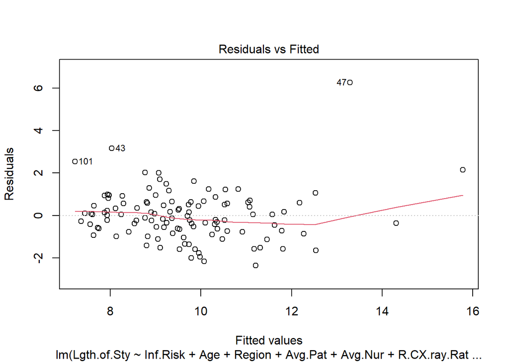

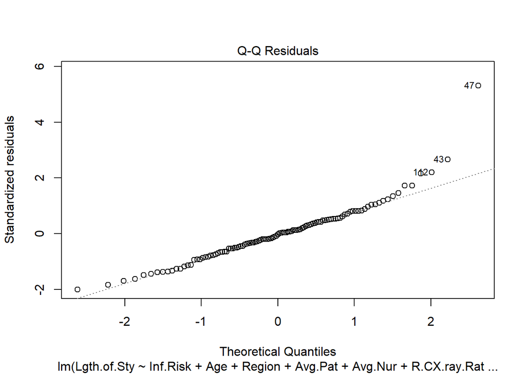

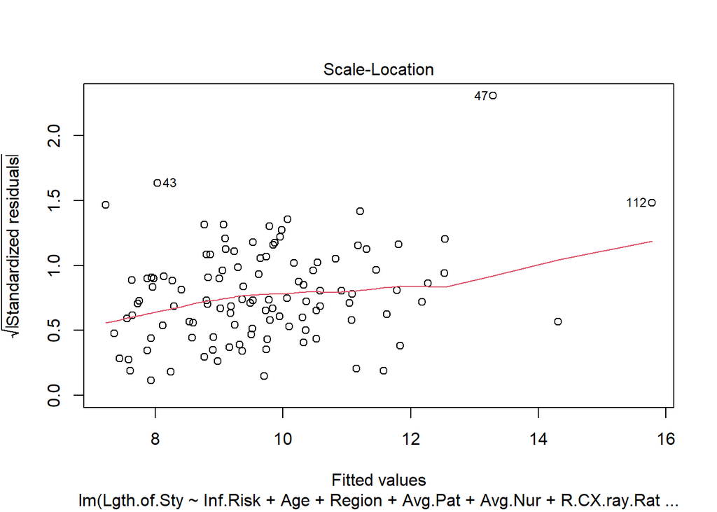

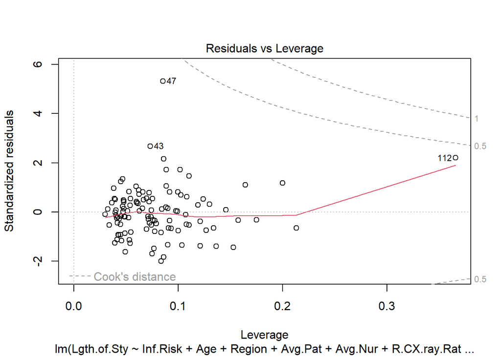

```r
fit2 = lm(Lgth.of.Sty ~ Inf.Risk + Age + Region + Avg.Pat + Avg.Nur + R.CX.ray.Rat, data = df)
plot(fit2)
```

```r
summary(fit2)
```

```
##
## Call:
## lm(formula = Lgth.of.Sty ~ Inf.Risk + Age + Region + Avg.Pat +
##     Avg.Nur + R.CX.ray.Rat, data = df)
##
## Residuals:
##     Min      1Q  Median      3Q     Max
## -2.3682 -0.7176 -0.0270  0.5994  6.2677
##
## Coefficients:
##               Estimate Std. Error t value Pr(>|t|)
## (Intercept)   3.044076   1.619812   1.879 0.063006 .
## Inf.Risk      0.455890   0.108565   4.199 5.66e-05 ***
## Age           0.072390   0.026850   2.696 0.008184 **
## RegionNC     -0.931548   0.330651  -2.817 0.005797 **
## RegionS      -1.223960   0.329493  -3.715 0.000329 ***
## RegionW      -2.005095   0.405992  -4.939 3.01e-06 ***
## Avg.Pat       0.009691   0.001881   5.152 1.23e-06 ***
## Avg.Nur      -0.007199   0.002056  -3.501 0.000684 ***
## R.CX.ray.Rat  0.013557   0.007050   1.923 0.057203 .
## ---
## Signif. codes:  0 '***' 0.001 '**' 0.01 '*' 0.05 '.' 0.1 ' ' 1
##
## Residual standard error: 1.232 on 104 degrees of freedom
## Multiple R-squared:  0.6143, Adjusted R-squared:  0.5846
## F-statistic:  20.7 on 8 and 104 DF,  p-value: < 2.2e-16
```

```r
vif(fit2)
```

```
##                  GVIF Df GVIF^(1/(2*Df))
## Inf.Risk     1.563795  1        1.250518
## Age          1.058917  1        1.029037
## Region       1.304026  3        1.045236
## Avg.Pat      6.171683  1        2.484287
## Avg.Nur      6.051790  1        2.460039
## R.CX.ray.Rat 1.375027  1        1.172616
```

We dropped number of beds (as noted above) as well as medical school affiliation, percent of available facilities, and routine culturing ratio, which were not statistically significant in the baseline model. This resulted in an adjusted r-squared of .5846, which is roughly the same as we had before.

Fit diagnostics are marginally improved in the reduced model, but not noticeably so. Overall, teh reduced model enhances interpretability by dropping statistically insignificant predictors, but it does not significantly improve the model fit.

## Model with Interactions

For the sake of simplicity in the inferential model, we limited our exploration of interactions to a few key variables, with a focus on infection risk since it is the subject of our inquiry and it seems to have the strongest linear relationship with length of stay. It seems intuitive that infection risk might interact with region, age, and average number of patients, so we examined the graphs of those interactions.

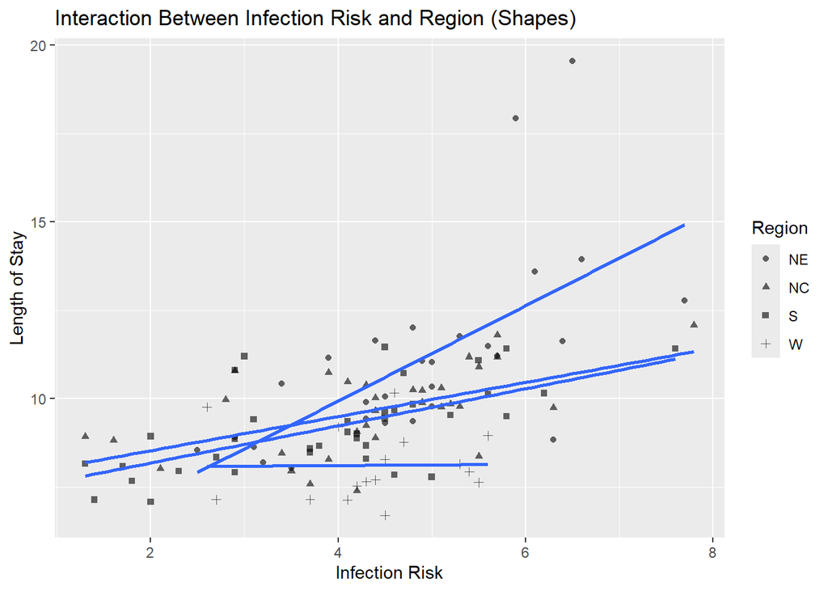

```r
ggplot(df, aes(x = Inf.Risk, y = Lgth.of.Sty, shape = Region)) +
  geom_point(alpha = 0.6) +
  geom_smooth(method = "lm", se = FALSE, aes(group = Region)) +
  labs(title = "Interaction Between Infection Risk and Region (Shapes)",
       x = "Infection Risk",
       y = "Length of Stay")
```

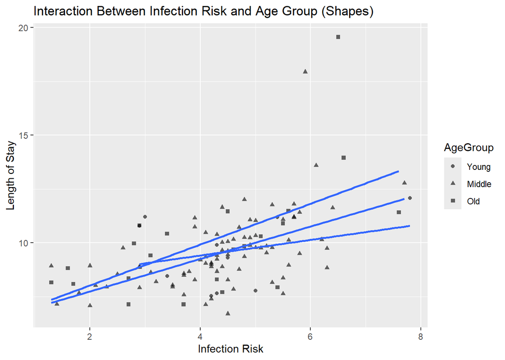

```r
df$AgeGroup = cut(df$Age, breaks = 3, labels = c("Young", "Middle", "Old"))

ggplot(df, aes(x = Inf.Risk, y = Lgth.of.Sty, shape = AgeGroup)) +
  geom_point(alpha = 0.6) +
  geom_smooth(method = "lm", se = FALSE, aes(group = AgeGroup)) +
  labs(title = "Interaction Between Infection Risk and Age Group (Shapes)",
       x = "Infection Risk",
       y = "Length of Stay")
```

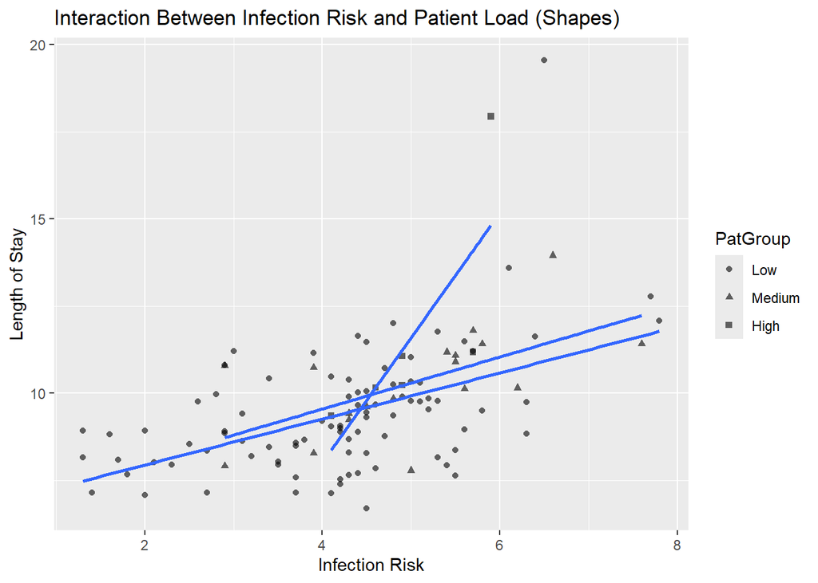

```r
df$PatGroup = cut(df$Avg.Pat, breaks = 3, labels = c("Low", "Medium", "High"))

ggplot(df, aes(x = Inf.Risk, y = Lgth.of.Sty, shape = PatGroup)) +
  geom_point(alpha = 0.6) +
  geom_smooth(method = "lm", se = FALSE, aes(group = PatGroup)) +
  labs(title = "Interaction Between Infection Risk and Patient Load (Shapes)",
       x = "Infection Risk",
       y = "Length of Stay")
```

Thus, we refit the model to incorporate interactions for Region/Infection Risk and Average Patients/Infection Risk.

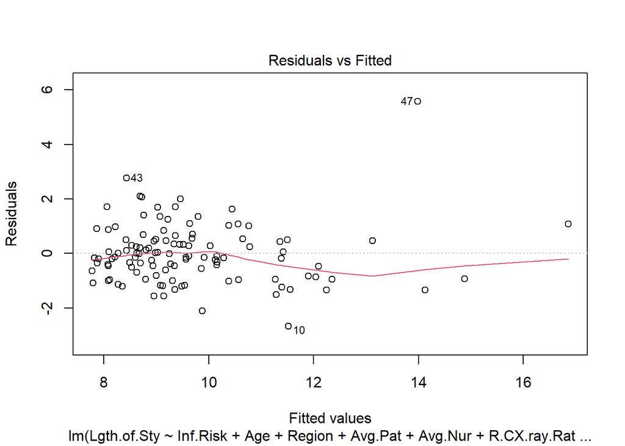

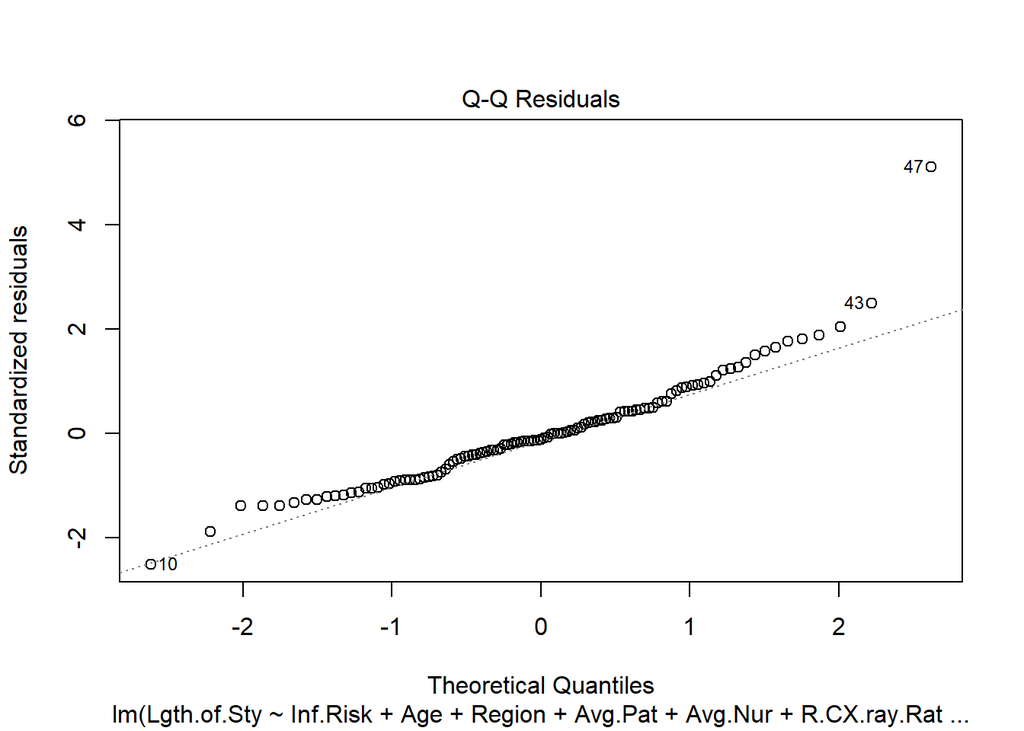

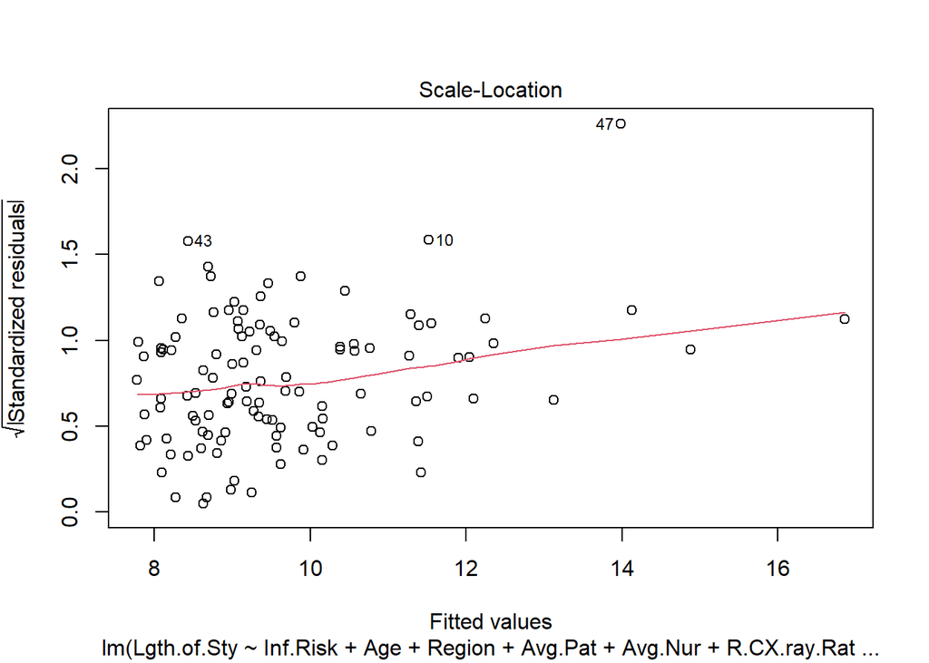

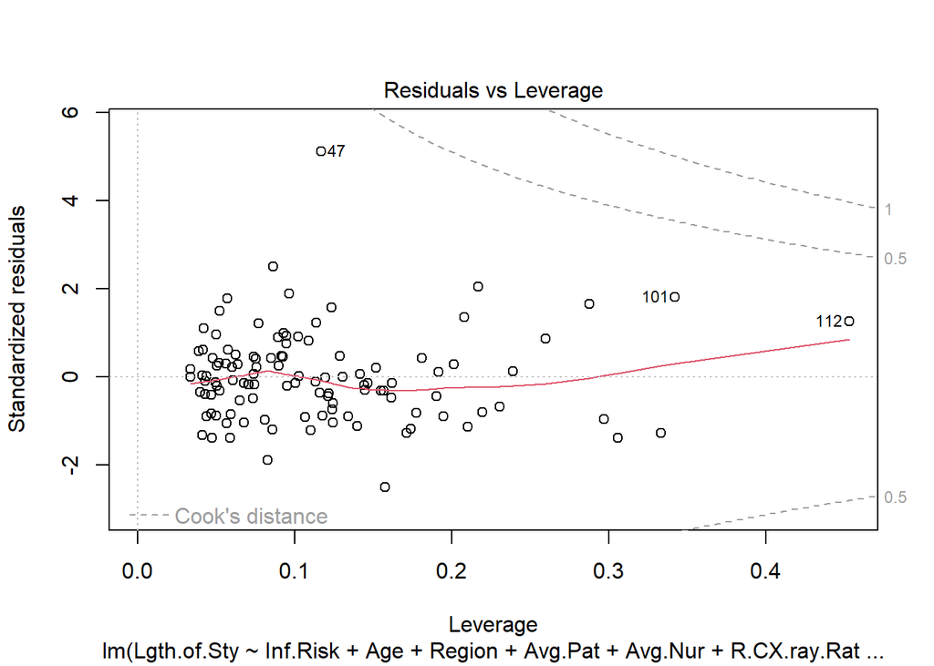

```r
fit3 = lm(Lgth.of.Sty ~ Inf.Risk + Age + Region + Avg.Pat + Avg.Nur + R.CX.ray.Rat + Inf.Risk*Region + Inf.Risk*Avg.Pat, data = df)

plot(fit3)
```

```r
summary(fit3)
```

```
##
## Call:
## lm(formula = Lgth.of.Sty ~ Inf.Risk + Age + Region + Avg.Pat +
##     Avg.Nur + R.CX.ray.Rat + Inf.Risk * Region + Inf.Risk * Avg.Pat,
##     data = df)
##
## Residuals:
##     Min      1Q  Median      3Q     Max
## -2.6773 -0.8109 -0.1223  0.5072  5.5787
##
## Coefficients:
##                    Estimate Std. Error t value Pr(>|t|)
## (Intercept)        3.985639   1.819101   2.191  0.03077 *
## Inf.Risk           0.682106   0.232880   2.929  0.00421 **
## Age                0.036648   0.027052   1.355  0.17856
## RegionNC           1.907190   1.159277   1.645  0.10308
## RegionS            1.626446   1.068473   1.522  0.13111
## RegionW            1.626691   1.803920   0.902  0.36935
## Avg.Pat           -0.001302   0.004530  -0.287  0.77440
## Avg.Nur           -0.005346   0.002025  -2.640  0.00961 **
## R.CX.ray.Rat       0.010691   0.006761   1.581  0.11696
## Inf.Risk:RegionNC -0.598620   0.243514  -2.458  0.01568 *
## Inf.Risk:RegionS  -0.616284   0.228075  -2.702  0.00810 **
## Inf.Risk:RegionW  -0.775807   0.398888  -1.945  0.05459 .
## Inf.Risk:Avg.Pat   0.001931   0.000776   2.488  0.01449 *
## ---
## Signif. codes:  0 '***' 0.001 '**' 0.01 '*' 0.05 '.' 0.1 ' ' 1
##
## Residual standard error: 1.161 on 100 degrees of freedom
## Multiple R-squared:  0.6705, Adjusted R-squared:  0.6309
## F-statistic: 16.96 on 12 and 100 DF,  p-value: < 2.2e-16
```

```r
vif(fit3, type = "predictor")
```

```
## GVIFs computed for predictors
```

```
##                   GVIF Df GVIF^(1/(2*Df))  Interacts With
## Inf.Risk     11.197235  9        1.143626 Region, Avg.Pat
## Age           1.209994  1        1.099997            --
## Region        4.628173  7        1.115653        Inf.Risk
## Avg.Pat      38.523406  3        1.837754        Inf.Risk
## Avg.Nur       6.603531  1        2.569734            --
## R.CX.ray.Rat  1.423499  1        1.193105            --
##                                              Other Predictors
## Inf.Risk                           Age, Avg.Nur, R.CX.ray.Rat
## Age          Inf.Risk, Region, Avg.Pat, Avg.Nur, R.CX.ray.Rat
## Region                    Age, Avg.Pat, Avg.Nur, R.CX.ray.Rat
## Avg.Pat                    Age, Region, Avg.Nur, R.CX.ray.Rat
## Avg.Nur          Inf.Risk, Age, Region, Avg.Pat, R.CX.ray.Rat
## R.CX.ray.Rat          Inf.Risk, Age, Region, Avg.Pat, Avg.Nur
```

The introduction of the interaction terms improved our adjusted R-squared value to .6309, and the VIF values are still acceptable.

Fit diagnostics remain consistent with the baseline model, which are acceptable but not perfect. Our last attempt to tame the residuals and improve the fit of the inferential model will be to apply log transformations to some of our predictors.

## Log Transformations on Average Daily Census and Number of Nurses

As seen in the univariate analysis, the distributions of both average number of patients and number of nurses are highly skewed, and the relationships between these predictors and length of stay are not perfectly linear.

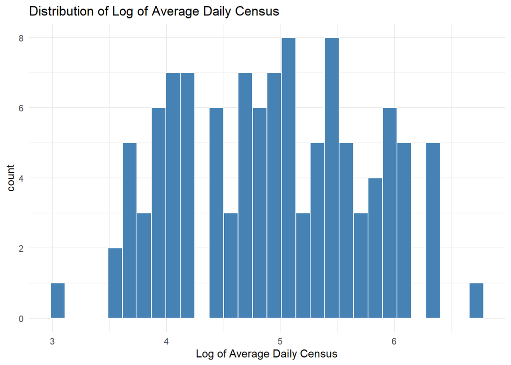

```r
log_Avg.Pat = log(df$Avg.Pat)
log_Avg.Nur = log(df$Avg.Nur)
df = df %>% mutate(log_Avg.Pat = log_Avg.Pat, log_Avg.Nur = log_Avg.Nur)

ggplot(df, aes(x = log_Avg.Pat)) +
  geom_histogram(fill = "steelblue", color = "white") +
  labs(
    x = "Log of Average Daily Census",
    title = "Distribution of Log of Average Daily Census"
  ) +
  theme_minimal()
```

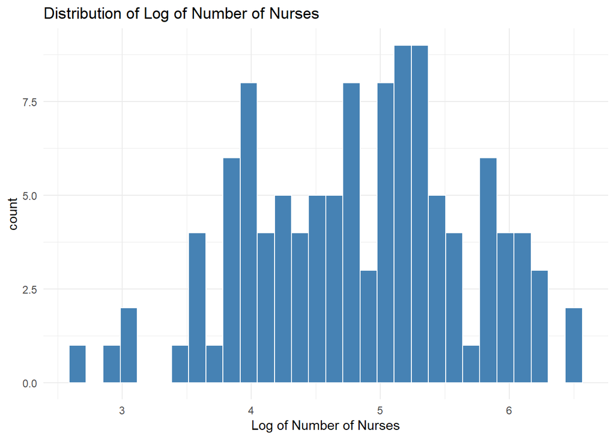

```r
ggplot(df, aes(x = log_Avg.Nur)) +
  geom_histogram(fill = "steelblue", color = "white") +
  labs(
    x = "Log of Number of Nurses",
    title = "Distribution of Log of Number of Nurses"
  ) +
  theme_minimal()
```

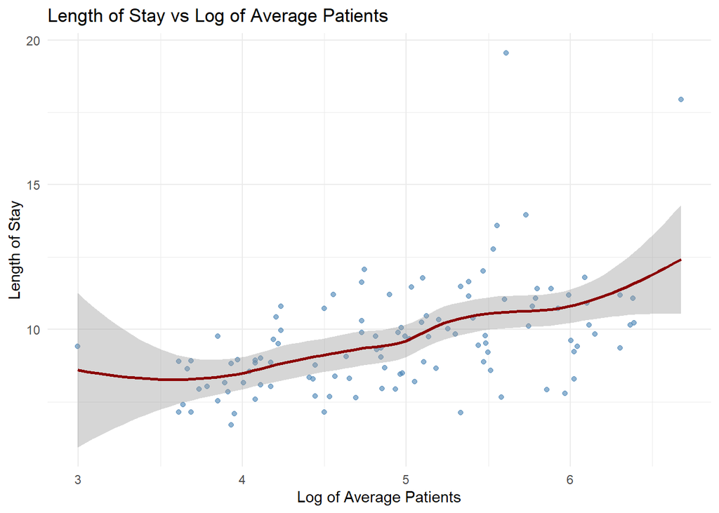

```r
ggplot(df, aes(x = log_Avg.Pat, y = Lgth.of.Sty)) +
  geom_point(alpha = 0.6, color = "steelblue") +
  geom_smooth(method = "loess", se = TRUE, color = "darkred", linetype = "solid") +
  labs(
    x = paste("Log of Average Patients"),
    y = "Length of Stay",
    title = paste("Length of Stay vs Log of Average Patients")
  ) +
  theme_minimal()
```

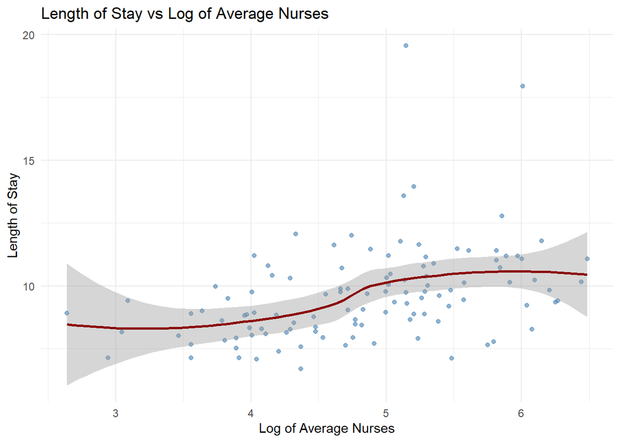

```r
ggplot(df, aes(x = log_Avg.Nur, y = Lgth.of.Sty)) +
  geom_point(alpha = 0.6, color = "steelblue") +
  geom_smooth(method = "loess", se = TRUE, color = "darkred", linetype = "solid") +
  labs(
    x = paste("Log of Average Nurses"),
    y = "Length of Stay",
    title = paste("Length of Stay vs Log of Average Nurses")
  ) +
  theme_minimal()
```

The distributions of the log-transformed variables certainly can’t be considered skewed! However, their relationships to the response variable are still barely linear. They aren’t that much less linear than our other non-infection risk predictors, so we will at least try with the log-transformed variables in our inferential model.

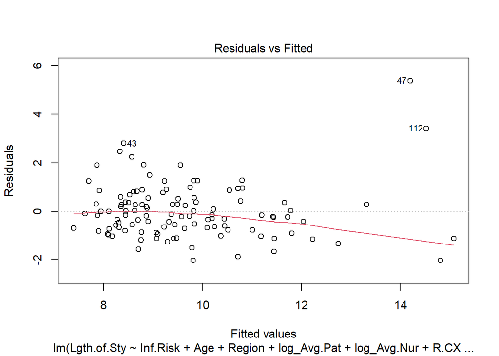

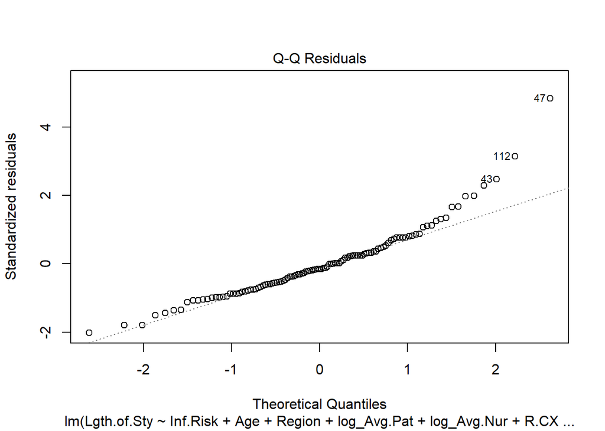

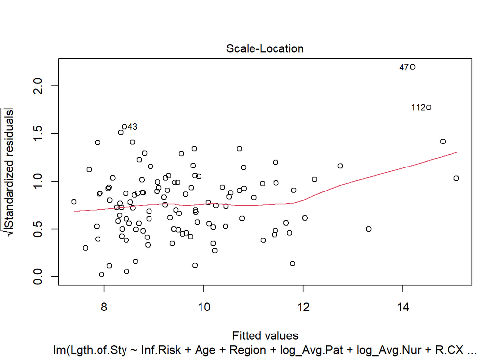

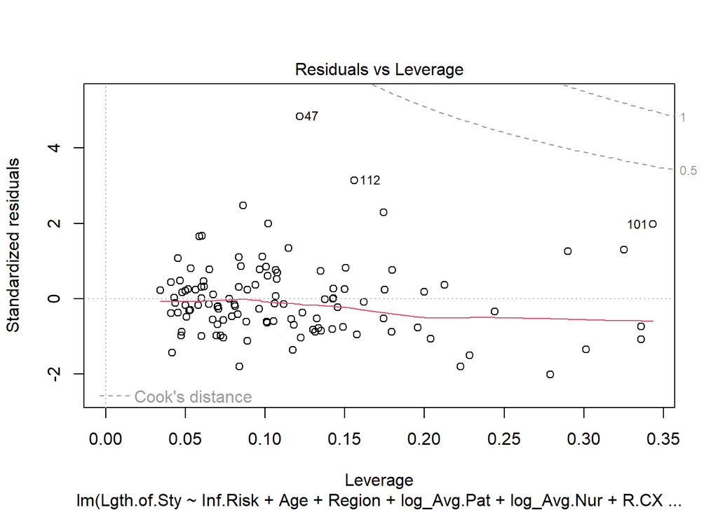

```r
fit4 = lm(Lgth.of.Sty ~ Inf.Risk + Age + Region + log_Avg.Pat + log_Avg.Nur + R.CX.ray.Rat + Inf.Risk*Region + Inf.Risk*log_Avg.Pat, data = df)
plot(fit4)
```

```r
summary(fit4)
```

```
##
## Call:
## lm(formula = Lgth.of.Sty ~ Inf.Risk + Age + Region + log_Avg.Pat +
##     log_Avg.Nur + R.CX.ray.Rat + Inf.Risk * Region + Inf.Risk *
##     log_Avg.Pat, data = df)
##
## Residuals:
##     Min      1Q  Median      3Q     Max
## -2.0300 -0.7199 -0.1663  0.5096  5.3650
##
## Coefficients:
##                       Estimate Std. Error t value Pr(>|t|)
## (Intercept)           8.796382   3.608078   2.438  0.01653 *
## Inf.Risk             -1.167630   0.677934  -1.722  0.08810 .
## Age                   0.042564   0.028043   1.518  0.13221
## RegionNC              1.426184   1.193324   1.195  0.23486
## RegionS               1.236361   1.113271   1.111  0.26942
## RegionW               0.921989   1.871405   0.493  0.62332
## log_Avg.Pat          -0.464946   0.729073  -0.638  0.52511
## log_Avg.Nur          -0.801132   0.382615  -2.094  0.03880 *
## R.CX.ray.Rat          0.013025   0.006968   1.869  0.06451 .
## Inf.Risk:RegionNC    -0.486948   0.250723  -1.942  0.05493 .
## Inf.Risk:RegionS     -0.535421   0.236719  -2.262  0.02587 *
## Inf.Risk:RegionW     -0.550814   0.418268  -1.317  0.19088
## Inf.Risk:log_Avg.Pat  0.430305   0.131466   3.273  0.00146 **
## ---
## Signif. codes:  0 '***' 0.001 '**' 0.01 '*' 0.05 '.' 0.1 ' ' 1
##
## Residual standard error: 1.183 on 100 degrees of freedom
## Multiple R-squared:  0.6581, Adjusted R-squared:  0.6171
## F-statistic: 16.04 on 12 and 100 DF,  p-value: < 2.2e-16
```

```r
vif(fit4)
```

```
## there are higher-order terms (interactions) in this model
## consider setting type = 'predictor'; see ?vif
```

```
##                             GVIF Df GVIF^(1/(2*Df))
## Inf.Risk               66.150100  1        8.133271
## Age                     1.253077  1        1.119409
## Region               4618.689072  3        4.080873
## log_Avg.Pat            27.867354  1        5.278954
## log_Avg.Nur             8.140321  1        2.853125
## R.CX.ray.Rat            1.457339  1        1.207203
## Inf.Risk:Region      4931.608385  3        4.125704
## Inf.Risk:log_Avg.Pat  102.549227  1       10.126659
```

## Final Inferential Model

Given the choice between the reduced model with interactions and the log-transformed model, we will proceed with the reduced model with interactions as our final inferential model. The log transformations did not significantly improve the fit of the model and had worse residual diagnostics. The reduced model with interactions has a higher adjusted R-squared value.

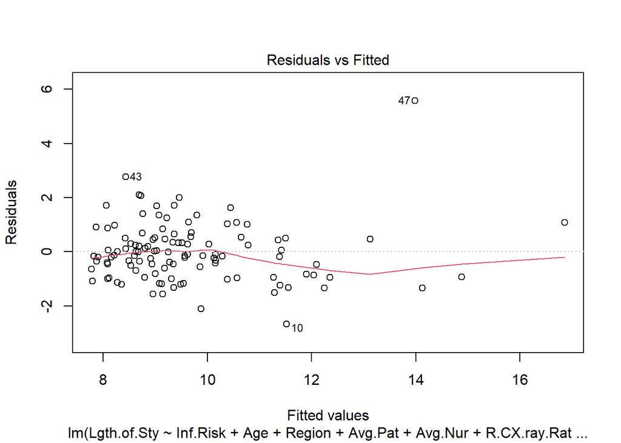

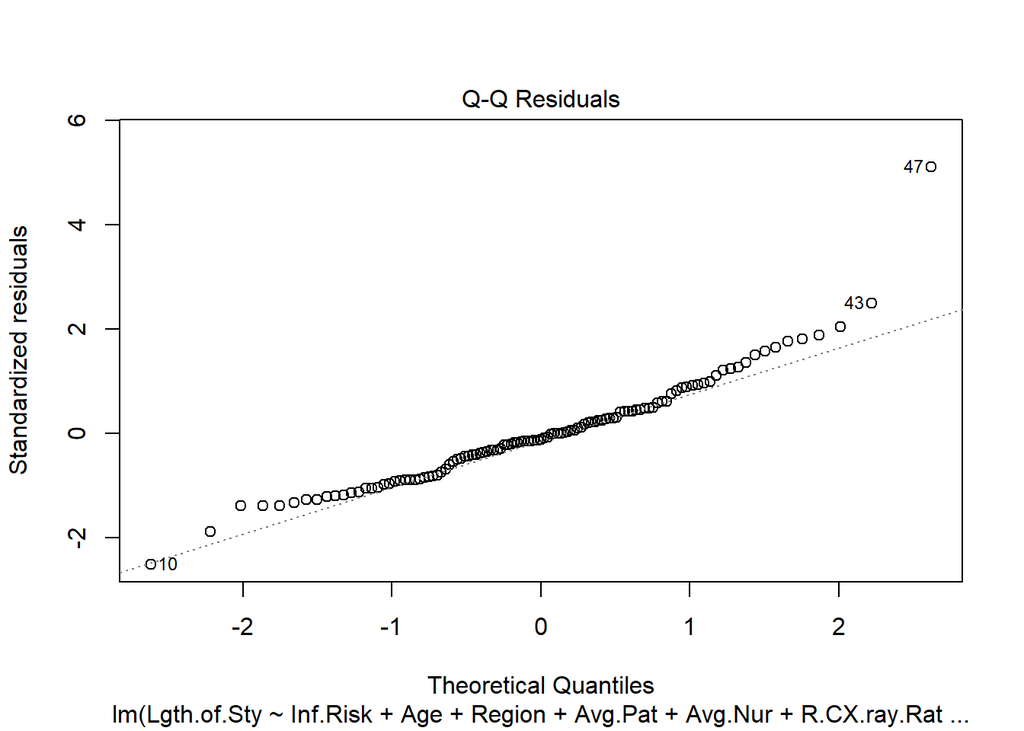

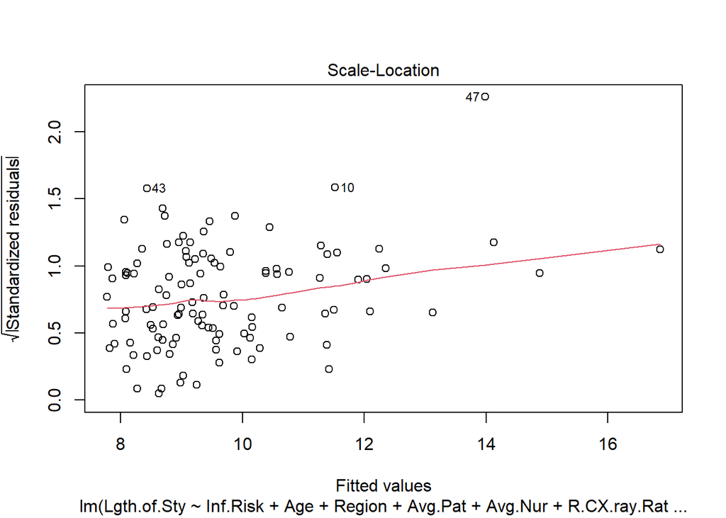

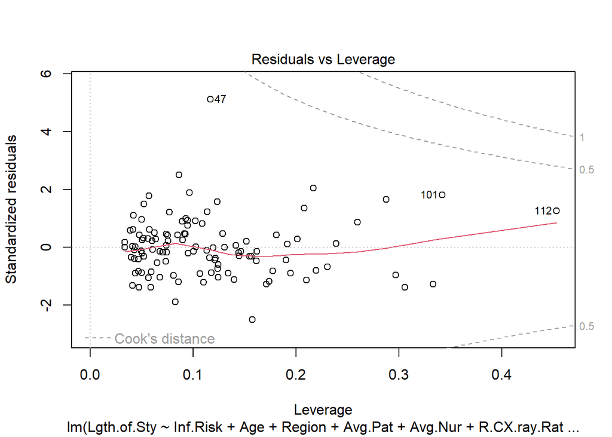

```r
final_inferential_mlr = lm(Lgth.of.Sty ~ Inf.Risk + Age + Region + Avg.Pat + Avg.Nur + R.CX.ray.Rat + Inf.Risk*Region + Inf.Risk*Avg.Pat, data = df)

plot(final_inferential_mlr)
```

```r
summary(final_inferential_mlr)
```

```
##
## Call:
## lm(formula = Lgth.of.Sty ~ Inf.Risk + Age + Region + Avg.Pat +
##     Avg.Nur + R.CX.ray.Rat + Inf.Risk * Region + Inf.Risk * Avg.Pat,
##     data = df)
##
## Residuals:
##     Min      1Q  Median      3Q     Max
## -2.6773 -0.8109 -0.1223  0.5072  5.5787
##
## Coefficients:
##                    Estimate Std. Error t value Pr(>|t|)
## (Intercept)        3.985639   1.819101   2.191  0.03077 *
## Inf.Risk           0.682106   0.232880   2.929  0.00421 **
## Age                0.036648   0.027052   1.355  0.17856
## RegionNC           1.907190   1.159277   1.645  0.10308
## RegionS            1.626446   1.068473   1.522  0.13111
## RegionW            1.626691   1.803920   0.902  0.36935
## Avg.Pat           -0.001302   0.004530  -0.287  0.77440
## Avg.Nur           -0.005346   0.002025  -2.640  0.00961 **
## R.CX.ray.Rat       0.010691   0.006761   1.581  0.11696
## Inf.Risk:RegionNC -0.598620   0.243514  -2.458  0.01568 *
## Inf.Risk:RegionS  -0.616284   0.228075  -2.702  0.00810 **
## Inf.Risk:RegionW  -0.775807   0.398888  -1.945  0.05459 .
## Inf.Risk:Avg.Pat   0.001931   0.000776   2.488  0.01449 *
## ---
## Signif. codes:  0 '***' 0.001 '**' 0.01 '*' 0.05 '.' 0.1 ' ' 1
##
## Residual standard error: 1.161 on 100 degrees of freedom
## Multiple R-squared:  0.6705, Adjusted R-squared:  0.6309
## F-statistic: 16.96 on 12 and 100 DF,  p-value: < 2.2e-16
```

## Bootstrap Confidence Interval for Infection Risk Coefficient

Since the specific question of interest is the relationship between infection risk and length of stay, we want to provide a robust confidence interval for the infection risk coefficient. Given the small sample size of 113 hospitals, we will use a bootstrap approach to estimate the confidence interval.

```r
boot.p = paired.boot(Lgth.of.Sty ~ Inf.Risk + Age + Region + Avg.Pat + Avg.Nur + R.CX.ray.Rat + Inf.Risk*Region + Inf.Risk*Avg.Pat, data = df, B = 10000, seed = 1234)
ci = t(apply(boot.p$bootEstParam, 2, quantile, probs = c(0.025, 0.975)))
print(ci)
```

```
##                            2.5%         97.5%
## (Intercept)       -0.8510403314  7.8089629705
## Inf.Risk           0.1282066169  1.4155832448
## Age               -0.0171987366  0.1004129219
## RegionNC          -0.5863509319  5.0598807153
## RegionS           -0.5553860182  4.5317388879
## RegionW           -2.5077399796  5.9856607766
## Avg.Pat           -0.0112671637  0.0087634028
## Avg.Nur           -0.0099053415 -0.0001082455
## R.CX.ray.Rat      -0.0014195571  0.0242137380
## Inf.Risk:RegionNC -1.3303120696 -0.0304586767
## Inf.Risk:RegionS  -1.2870478907 -0.0803568926
## Inf.Risk:RegionW  -1.7586328950  0.1391811035
## Inf.Risk:Avg.Pat   0.0001250797  0.0036671759
```

Based on the bootstrap confidence interval, we are 95% coonfident that for each 1-unit increase in Infection Risk, the mean Length of Stay increases by somewhere between 0.13 and 1.42 days, holding other factors constant.

# Predictive Model 1: Complex MLR

## Stepwise Feature Selection

We are very pleased with the results of our inferential model, which prioritizes interpretability and provides a robust confidence interval for the infection risk coefficient. Because our predictive MLR has different goals, we will use different tools for feature selection, starting with a stepwise feature selection approach.

```r
empty_model = lm(Lgth.of.Sty ~ 1, data = df)
full_model = lm(Lgth.of.Sty ~  (Inf.Risk + Age + R.Cul.Rat + R.CX.ray.Rat + N.Beds + Med.Sc.Aff + Region + Avg.Pat + Avg.Nur + Pct.Ser.Fac)^2, data = df)
stepwise_model = step(empty_model, scope = list(lower = empty_model, upper = full_model), direction = "both", trace = 0)
summary(stepwise_model)
```

```
##
## Call:
## lm(formula = Lgth.of.Sty ~ Inf.Risk + Region + Avg.Pat + Avg.Nur +
##     R.CX.ray.Rat + Inf.Risk:Avg.Pat + Inf.Risk:Region + Inf.Risk:Avg.Nur +
##     Inf.Risk:R.CX.ray.Rat, data = df)
##
## Residuals:
##     Min      1Q  Median      3Q     Max
## -2.5356 -0.6554 -0.1379  0.5356  5.2135
##
## Coefficients:
##                        Estimate Std. Error t value Pr(>|t|)
## (Intercept)            8.097438   2.044453   3.961 0.000141 ***
## Inf.Risk               0.201701   0.473665   0.426 0.671156
## RegionNC               2.139106   1.201385   1.781 0.078056 .
## RegionS                1.677773   1.201674   1.396 0.165778
## RegionW                1.658892   1.788868   0.927 0.356004
## Avg.Pat               -0.015838   0.008777  -1.804 0.074207 .
## Avg.Nur                0.013133   0.009873   1.330 0.186498
## R.CX.ray.Rat          -0.020555   0.022149  -0.928 0.355653
## Inf.Risk:Avg.Pat       0.004740   0.001636   2.897 0.004636 **
## Inf.Risk:RegionNC     -0.655579   0.252075  -2.601 0.010727 *
## Inf.Risk:RegionS      -0.598844   0.261237  -2.292 0.024003 *
## Inf.Risk:RegionW      -0.782430   0.395998  -1.976 0.050956 .
## Inf.Risk:Avg.Nur      -0.003655   0.001905  -1.919 0.057863 .
## Inf.Risk:R.CX.ray.Rat  0.006785   0.004781   1.419 0.159023
## ---
## Signif. codes:  0 '***' 0.001 '**' 0.01 '*' 0.05 '.' 0.1 ' ' 1
##
## Residual standard error: 1.151 on 99 degrees of freedom
## Multiple R-squared:  0.6794, Adjusted R-squared:  0.6373
## F-statistic: 16.14 on 13 and 99 DF,  p-value: < 2.2e-16
```

```r
vif(stepwise_model, type = "predictor")
```

```
## GVIFs computed for predictors
```

```
##                    GVIF Df GVIF^(1/(2*Df))
## Inf.Risk        1.00000 13        1.000000
## Region         32.53137  7        1.282394
## Avg.Pat      1041.45142  3        3.183756
## Avg.Nur      1113.09962  3        3.219257
## R.CX.ray.Rat   14.77139  3        1.566403
##                                      Interacts With
## Inf.Risk     Avg.Pat, Region, Avg.Nur, R.CX.ray.Rat
## Region                                     Inf.Risk
## Avg.Pat                                    Inf.Risk
## Avg.Nur                                    Inf.Risk
## R.CX.ray.Rat                               Inf.Risk
##                            Other Predictors
## Inf.Risk                               --
## Region       Avg.Pat, Avg.Nur, R.CX.ray.Rat
## Avg.Pat       Region, Avg.Nur, R.CX.ray.Rat
## Avg.Nur       Region, Avg.Pat, R.CX.ray.Rat
## R.CX.ray.Rat       Region, Avg.Pat, Avg.Nur
```

## Using Lasso Regression to Select Interactions

```r
X = model.matrix(Lgth.of.Sty ~  (Inf.Risk + Age + R.Cul.Rat + R.CX.ray.Rat + N.Beds + Med.Sc.Aff + Region + Avg.Pat + Avg.Nur + Pct.Ser.Fac)^2, data = df)[ , -1]

y = df$Lgth.of.Sty

set.seed(1234)
lasso_cv = cv.glmnet(X, y, alpha = 1, family = "gaussian")
beta = as.matrix(coef(lasso_cv, s = "lambda.1se"))[-1 , , drop = FALSE]
keep = beta[beta != 0 , , drop = FALSE]

selected = data.frame(term = rownames(keep), coef = as.vector(keep))
selected[order(abs(selected$coef), decreasing = TRUE), ]
```

```
##                    term          coef
## 7  Med.Sc.AffNo:RegionW -0.4098992758
## 4      Inf.Risk:RegionW -0.0948956065
## 1                   Age  0.0149384421
## 3 Inf.Risk:R.CX.ray.Rat  0.0031612025
## 2          Inf.Risk:Age  0.0010617190
## 5      Inf.Risk:Avg.Pat  0.0006646077
## 6        N.Beds:RegionS -0.0003290896
```

```r
set.seed(1234)

control = trainControl(method = "repeatedcv", number = 10, repeats = 5, savePredictions = "final")

final_predictive_mlr = train(Lgth.of.Sty ~ Inf.Risk + Region + Avg.Pat + Avg.Nur + R.CX.ray.Rat + Age + Med.Sc.Aff + N.Beds + Inf.Risk:Avg.Pat + Inf.Risk:Region + Inf.Risk:Avg.Nur + Inf.Risk:R.CX.ray.Rat + Inf.Risk:Age + Med.Sc.Aff:Region + N.Beds:Region, data = df, method = "lm", trControl = control)
summary(final_predictive_mlr)
```

```
##
## Call:
## lm(formula = .outcome ~ ., data = dat)
##
## Residuals:
##     Min      1Q  Median      3Q     Max
## -2.3578 -0.5729 -0.1096  0.5384  5.0946
##
## Coefficients:
##                          Estimate Std. Error t value Pr(>|t|)
## (Intercept)              2.049564   5.444926   0.376   0.7075
## Inf.Risk                 0.776408   1.143785   0.679   0.4990
## RegionNC                 4.094437   1.791366   2.286   0.0246 *
## RegionS                  2.767379   1.782757   1.552   0.1241
## RegionW                  4.040048   2.430507   1.662   0.1000 .
## Avg.Pat                 -0.003553   0.011453  -0.310   0.7571
## Avg.Nur                  0.001451   0.011205   0.130   0.8973
## R.CX.ray.Rat            -0.014857   0.023131  -0.642   0.5223
## Age                      0.077846   0.087423   0.890   0.3756
## Med.Sc.AffNo             1.194450   0.741817   1.610   0.1109
## N.Beds                   0.001666   0.004677   0.356   0.7226
## `Inf.Risk:Avg.Pat`       0.002572   0.001911   1.346   0.1818
## `Inf.Risk:RegionNC`     -0.552986   0.285121  -1.939   0.0556 .
## `Inf.Risk:RegionS`      -0.343791   0.302085  -1.138   0.2581
## `Inf.Risk:RegionW`      -0.746249   0.406045  -1.838   0.0694 .
## `Inf.Risk:Avg.Nur`      -0.001416   0.002168  -0.653   0.5156
## `Inf.Risk:R.CX.ray.Rat`  0.005762   0.005078   1.135   0.2596
## `Inf.Risk:Age`          -0.009830   0.019091  -0.515   0.6079
## `RegionNC:Med.Sc.AffNo` -1.826793   1.093988  -1.670   0.0985 .
## `RegionS:Med.Sc.AffNo`  -1.277834   1.071006  -1.193   0.2360
## `RegionW:Med.Sc.AffNo`  -2.334071   1.583403  -1.474   0.1440
## `RegionNC:N.Beds`       -0.003464   0.002651  -1.307   0.1947
## `RegionS:N.Beds`        -0.004503   0.002257  -1.995   0.0491 *
## `RegionW:N.Beds`        -0.001945   0.003175  -0.613   0.5417
## ---
## Signif. codes:  0 '***' 0.001 '**' 0.01 '*' 0.05 '.' 0.1 ' ' 1
##
## Residual standard error: 1.148 on 89 degrees of freedom
## Multiple R-squared:  0.7132, Adjusted R-squared:  0.6391
## F-statistic: 9.622 on 23 and 89 DF,  p-value: 1.386e-15
```

```r
final_predictive_mlr$results
```

```
##   intercept     RMSE  Rsquared      MAE    RMSESD RsquaredSD     MAESD
## 1      TRUE 1.366162 0.5283689 1.047827 0.3875613  0.2369475 0.2505423
```

# Predictive Model 2: Random Forest

```r
set.seed(1234)

grid = expand.grid(mtry = 1:10)

control2 = trainControl(method = "repeatedcv", number = 10, repeats = 5)

fit6 = train(Lgth.of.Sty ~ ., data = df, method = "rf", trControl = control2, tuneGrid = grid, importance = TRUE)
fit6$results
```

```
##    mtry     RMSE  Rsquared      MAE    RMSESD RsquaredSD     MAESD
## 1     1 1.417396 0.4715317 1.045307 0.6132996  0.2228805 0.2817389
## 2     2 1.358897 0.4902939 1.026189 0.5793970  0.2237472 0.2796710
## 3     3 1.354126 0.4937754 1.022521 0.5616085  0.2216017 0.2773962
## 4     4 1.354826 0.4965018 1.024014 0.5519897  0.2250221 0.2766641
## 5     5 1.356233 0.4956071 1.028530 0.5464818  0.2220547 0.2704540
## 6     6 1.362857 0.4902576 1.034187 0.5321847  0.2261803 0.2674769
## 7     7 1.368760 0.4891215 1.033881 0.5289741  0.2263417 0.2633830
## 8     8 1.371702 0.4890776 1.038548 0.5240520  0.2205327 0.2650916
## 9     9 1.374330 0.4892356 1.037136 0.5207456  0.2213405 0.2620326
## 10   10 1.378433 0.4864474 1.040239 0.5154073  0.2246732 0.2606208
```

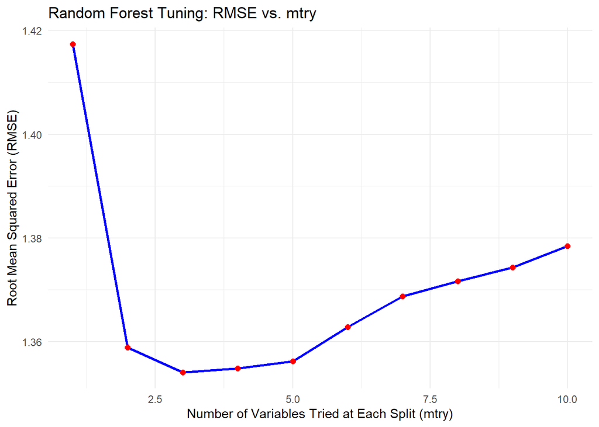

```r
ggplot(fit6$results, aes(x = mtry, y = RMSE)) +
  geom_line(color = "blue", size = 1) +
  geom_point(color = "red", size = 2) +
  labs(title = "Random Forest Tuning: RMSE vs. mtry",
       x = "Number of Variables Tried at Each Split (mtry)",
       y = "Root Mean Squared Error (RMSE)") +
  theme_minimal()
```

```r
final_forest = train(Lgth.of.Sty ~ ., data = df, method = "rf", trControl = control2, tuneGrid = expand.grid(mtry = 3), importance = TRUE)
final_forest$results
```

```
##   mtry    RMSE  Rsquared      MAE    RMSESD RsquaredSD     MAESD
## 1    3 1.34368 0.4988097 1.005769 0.5310893  0.1980141 0.2510673
```

# Model Comparison

[output not shown]

# Appendix

## Code Attribution

## Data Sources

## References